# Assignment_4

```r
## All files relating to this assignment can be found at https://github.com/Dylan-Hamilton3412/64060_-Dhamil28
## Import required libraries for data manipulation and cluster analysis
library(tidyverse)
library(dplyr)
library(factoextra)
library(ISLR)

## Set seed to ensure reproducibility of the K-means results
set.seed(123)

## Read in the pharmaceutical dataset and review summary statistics
Base_Data <- read.csv("Pharmaceuticals.csv")
summary(Base_Data)
```

```
    Symbol              Name             Market_Cap          Beta           PE_Ratio          ROE
 Length:21          Length:21          Min.   :  0.41   Min.   :0.1800   Min.   : 3.60   Min.   : 3.9
 Class :character   Class :character   1st Qu.:  6.30   1st Qu.:0.3500   1st Qu.:18.90   1st Qu.:14.9
 Mode  :character   Mode  :character   Median : 48.19   Median :0.4600   Median :21.50   Median :22.6
                                       Mean   : 57.65   Mean   :0.5257   Mean   :25.46   Mean   :25.8
                                       3rd Qu.: 73.84   3rd Qu.:0.6500   3rd Qu.:27.90   3rd Qu.:31.0
                                       Max.   :199.47   Max.   :1.1100   Max.   :82.50   Max.   :62.9
      ROA        Asset_Turnover    Leverage        Rev_Growth    Net_Profit_Margin Median_Recommendation
 Min.   : 1.40   Min.   :0.3    Min.   :0.0000   Min.   :-3.17   Min.   : 2.6      Length:21
 1st Qu.: 5.70   1st Qu.:0.6    1st Qu.:0.1600   1st Qu.: 6.38   1st Qu.:11.2      Class :character
 Median :11.20   Median :0.6    Median :0.3400   Median : 9.37   Median :16.1      Mode  :character
 Mean   :10.51   Mean   :0.7    Mean   :0.5857   Mean   :13.37   Mean   :15.7
 3rd Qu.:15.00   3rd Qu.:0.9    3rd Qu.:0.6000   3rd Qu.:21.87   3rd Qu.:21.1
 Max.   :20.30   Max.   :1.1    Max.   :3.5100   Max.   :34.21   Max.   :25.5
   Location           Exchange
 Length:21          Length:21
 Class :character   Class :character
 Mode  :character   Mode  :character
```

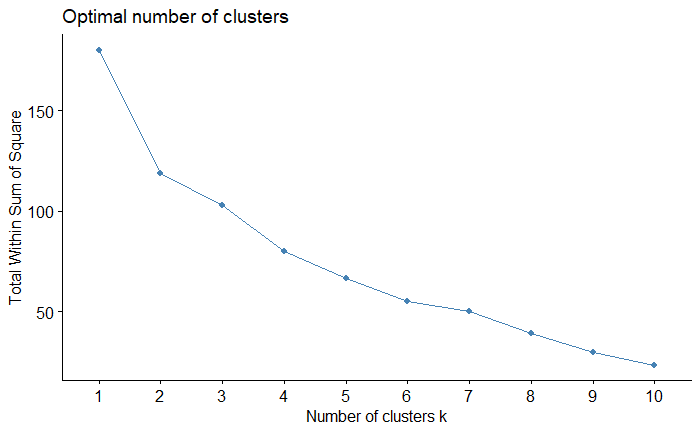

```r
##Part A

## Create a data frame containing only the numerical variables used for clustering
Num_Data <- select(Base_Data, 3:11)

## Standardize all variables using z-scores so that no variable dominates due to scale
Num_Data <- scale(Num_Data,)
Num_Data <- as.data.frame(Num_Data)

## Run an elbow chart to determine the best fit of K without over-fitting the algorithm
fviz_nbclust(Num_Data, kmeans, method = "wss")
```

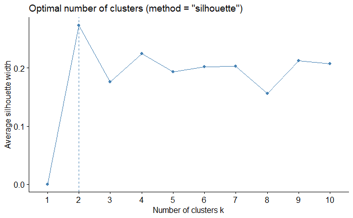

```r
## Confirm the choice of K using silhouette values to maximize cluster separation
fviz_nbclust(Num_Data, kmeans, method = "silhouette")
```

```r
## Based on both methods, K = 2 appears to provide a reasonable balance between cluster separation and model complexity
Num_KClust <- kmeans(Num_Data, centers = 2, nstart = 25)
## Display the number of companies assigned to each cluster
Num_KClust$size
```

```
[1] 11 10
```

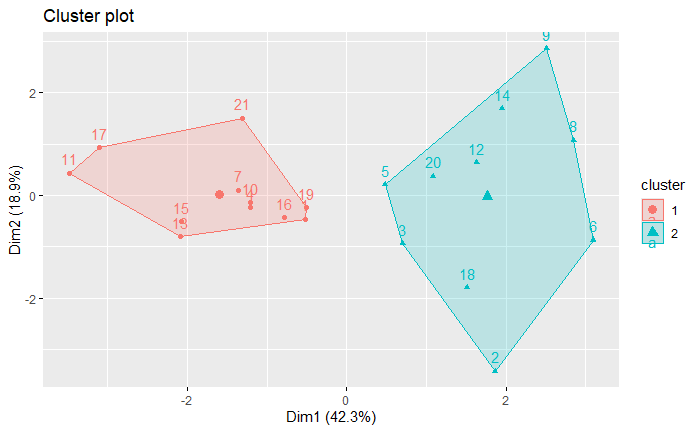

```r
## Visualize the clusters using a plot
fviz_cluster(Num_KClust, data = Num_Data)
```

```r
## Append cluster assignments to both the scaled numerical data and the original dataset
Num_Data <- cbind(Num_Data, "Cluster" = Num_KClust$cluster)
Base_Data <- cbind(Base_Data, "Cluster" = Num_KClust$cluster)
```

Choices made in this cluster model were based off simple modeling techniques learned prior in this course. First after separating the data into the strictly numerical variables we then normalized the data set to equilateral the weights of all variables. Since we are assuming no industry knowledge if we were to not normalize the values we would have variables such as market capitalization being weighted more heavily. Along with the normalization we will use the K means or Euclidean distances since we are working with strictly numerical data points and the main goal being lumping the companies into homogeneous clusters. In order to verify the number of K clusters I used the elbow method along with the silhouette method learned in this chapter to gather optimal K

```r
##Part B

## Calculate average values for each variable within each cluster to aid interpretation
Cluster_Means <- aggregate(Base_Data[,3:11], by = list(Cluster = Base_Data$Cluster), mean)
Cluster_Means
```

| Cluster | Market_Cap | Beta | PE_Ratio | ROE | ROA | Asset_Turnover | Leverage | Rev_Growth | Net_Profit_Margin |
| --- | --- | --- | --- | --- | --- | --- | --- | --- | --- |
| 1 | 97.11364 | 0.4336364 | 20.95455 | 35.7 | 14.95455 | 0.80 | 0.3254545 | 10.16455 | 20.17273 |
| 2 | 14.24300 | 0.6270000 | 30.42000 | 14.9 | 5.63000 | 0.59 | 0.8720000 | 16.89800 | 10.77000 |

```r
## Export cluster means for further examination. File added to GitHub along with assignment
write.csv(Cluster_Means, "Cluster_Means.csv", row.names = FALSE)

## Compare cluster averages against overall dataset averages to identify distinguishing characteristics
summary(Base_Data)
```

```
    Symbol              Name             Market_Cap          Beta           PE_Ratio          ROE
 Length:21          Length:21          Min.   :  0.41   Min.   :0.1800   Min.   : 3.60   Min.   : 3.9
 Class :character   Class :character   1st Qu.:  6.30   1st Qu.:0.3500   1st Qu.:18.90   1st Qu.:14.9
 Mode  :character   Mode  :character   Median : 48.19   Median :0.4600   Median :21.50   Median :22.6
                                       Mean   : 57.65   Mean   :0.5257   Mean   :25.46   Mean   :25.8
                                       3rd Qu.: 73.84   3rd Qu.:0.6500   3rd Qu.:27.90   3rd Qu.:31.0
                                       Max.   :199.47   Max.   :1.1100   Max.   :82.50   Max.   :62.9
      ROA        Asset_Turnover    Leverage        Rev_Growth    Net_Profit_Margin Median_Recommendation
 Min.   : 1.40   Min.   :0.3    Min.   :0.0000   Min.   :-3.17   Min.   : 2.6      Length:21
 1st Qu.: 5.70   1st Qu.:0.6    1st Qu.:0.1600   1st Qu.: 6.38   1st Qu.:11.2      Class :character
 Median :11.20   Median :0.6    Median :0.3400   Median : 9.37   Median :16.1      Mode  :character
 Mean   :10.51   Mean   :0.7    Mean   :0.5857   Mean   :13.37   Mean   :15.7
 3rd Qu.:15.00   3rd Qu.:0.9    3rd Qu.:0.6000   3rd Qu.:21.87   3rd Qu.:21.1
 Max.   :20.30   Max.   :1.1    Max.   :3.5100   Max.   :34.21   Max.   :25.5
   Location           Exchange            Cluster
 Length:21          Length:21          Min.   :1.000
 Class :character   Class :character   1st Qu.:1.000
 Mode  :character   Mode  :character   Median :1.000
                                       Mean   :1.476
                                       3rd Qu.:2.000
                                       Max.   :2.000
```

Cluster 1: Large-cap firms with low risk and leverage. Strong profitability and efficiency measures, but lower revenue growth, indicating mature and financially stable companies.

Cluster 2: Smaller firms with higher risk and leverage. Higher revenue growth and P/E ratios, but lower profitability, suggesting younger, growth-oriented companies.

```r
##Part C

## Examine whether variables not used in clustering exhibit any patterns across clusters

## Compare analyst recommendations by cluster
table(Base_Data$Cluster, Base_Data$Median_Recommendation)
```

```
    Hold Moderate Buy Moderate Sell Strong Buy
  1    6            3             2          0
  2    3            4             2          1
```

```r
## Compare headquarters locations by cluster
table(Base_Data$Cluster, Base_Data$Location)
```

```
    CANADA FRANCE GERMANY IRELAND SWITZERLAND UK US
  1      0      0       0       0           1  2  8
  2      1      1       1       1           0  1  5
```

```r
## Compare stock exchange listings by cluster
table(Base_Data$Cluster, Base_Data$Exchange)
```

```
    AMEX NASDAQ NYSE
  1    0      0   11
  2    1      1    8
```

When examining the variables not used in the clustering process, several patterns emerge. With respect to analyst recommendations, both clusters are primarily composed of firms receiving Hold and Moderate Buy ratings. However, Cluster 2 contains the only Strong Buy recommendation in the dataset, suggesting somewhat more favorable analyst sentiment. In terms of headquarters location, Cluster 1 is dominated by U.S.-based firms, while Cluster 2 exhibits greater geographic diversity, containing firms headquartered in Canada and several European countries. Finally, a clear pattern is observed with respect to stock exchange listing. Every firm in Cluster 1 is listed on the NYSE, whereas Cluster 2 contains the only firms listed on the AMEX and NASDAQ exchanges. Overall, although the clustering was based solely on financial variables, some differences in analyst sentiment, geographic location, and exchange listing are evident across the two groups.

```r
## Part D

## Assign descriptive names to summarize the financial characteristics of each cluster

## Cluster 1: Mature Industry Leaders
## Cluster 2: Emerging Growth Firms
```

Cluster 1 was labeled ‘Mature Industry Leaders’ because these firms possess larger market capitalization, lower risk and leverage, and stronger profitability measures. Although their revenue growth is lower, they exhibit the characteristics of established and financially stable companies. Cluster 2 was labeled ‘Emerging Growth Firms’ because these companies tend to be smaller, exhibit higher risk and leverage, and experience stronger revenue growth. Despite their growth potential and higher valuation ratios, these firms generate lower returns and profit margins, suggesting that they are still developing relative to the larger firms in Cluster 1.

[output not shown]